# Reshaping data

Markus & Esko

August 22, 2016

# Reshaping data

When using SPSS, you are quite often forced to reshape data between long and wide format. Certain analyses or plots of a certain type require the data in one format or the other. In R, such conversions between data formats are not necessary as often, but being able to do the trick is still a necessary skill in R.

Oftentimes when using ggplot2 to create graphics you may need to reshape the data frames. In ggplot, the variables of the data frame are mapped to the elements of the plot: for example, the values of variable A can be plotted on the x-axis and the values of variable B on the y-axis. The values to be mapped need to be located on a single row of the data frame. Other variables could be mapped to yet different properties, such as color, shape, etc.

## Long to wide (dataset *gameraw* contains the raw data)

```r
library(plyr)
library(car)

# Let's first load in the data and re-calculate the necessary variables:

gameraw <- read.table("kr_gameraw.txt", header=TRUE)
gameraw$set <- recode(gameraw$video_id,"0:9=1; 10:19=2; 20:29=3")
gameraw$set <- ordered(gameraw$set)
aggregated <- ddply(gameraw, .(age_grp, player_id, set, gender), summarize,
                Phit = mean(hit),
                PcorrectRejection = mean(correctRejection),
                accuracy = Phit + PcorrectRejection)
head(aggregated)
```

```
##   age_grp  player_id set gender      Phit PcorrectRejection  accuracy
## 1       A 2016020202   1   Mies 0.5217391         0.2173913 0.7391304
## 2       A 2016020202   2   Mies 0.5357143         0.4285714 0.9642857
## 3       A 2016020202   3   Mies 0.5000000         0.3928571 0.8928571
## 4       A 2016020302   1 Nainen 0.5384615         0.4230769 0.9615385
## 5       A 2016020302   2 Nainen 0.4615385         0.3461538 0.8076923
## 6       A 2016020302   3 Nainen 0.5185185         0.2962963 0.8148148
```

```r
# There are different ways to transform data from the long format to the wide format.
# We'll use the package reshape2 in this example:

library(reshape2)

# The command to do the trick is called dcast.

# The first argument is the data set to transform. Then, there's a formula which
# describes first the id-variables ("player_id" would suffice, but below we mention the
# variable "gender" as well to include it in the wide data set) and then the variable
# that identifies the recurring measurements (variable "set"). The third argument,
# "value.var" identifies the variable that contains the measurements:

game.wide <- dcast(aggregated, gender + player_id ~ set, value.var = "accuracy")

head(game.wide)
```

```
##   gender  player_id         1         2         3
## 1   Mies 2016020202 0.7391304 0.9642857 0.8928571
## 2   Mies 2016020402 0.8076923 0.9230769 0.7037037
## 3   Mies 2016020802 0.7857143 0.6538462 0.7200000
## 4   Mies 2016020804 0.6785714 0.7037037 0.7083333
## 5   Mies 2016020805 0.6153846 0.8846154 1.0000000
## 6   Mies 2016020806 0.7407407 0.6400000 0.8888889
```

```r
# Let's give the variables better names:
names(game.wide) <- c("gender", "player_id", paste("set", sep="", 1:3))
```

Now we could visualize how performance in the first set is related to the performance in the third set. This is not something you could easily do in the long format.

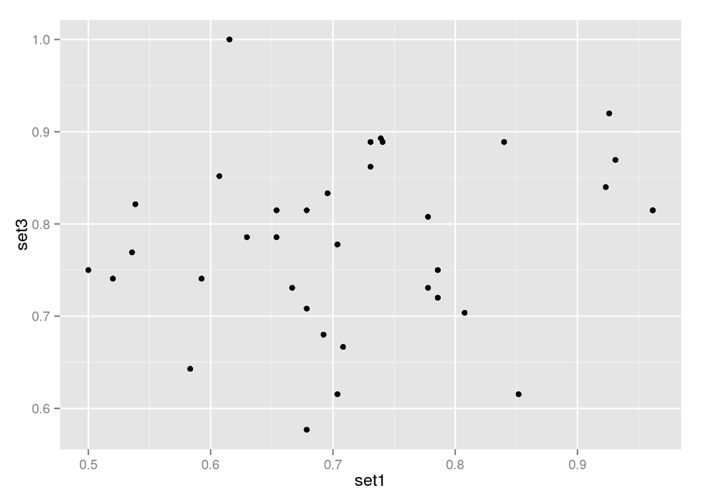

```r
require(ggplot2)
ggplot(game.wide, aes(x=set1, y=set3)) + geom_point()
```

```r
# Let's also calculate the variance-covariance matrix and the correlation matrix:
cov(game.wide[,3:5])
```

```
##             set1        set2        set3
## set1 0.013870026 0.003337302 0.002013757
## set2 0.003337302 0.016795564 0.005318986
## set3 0.002013757 0.005318986 0.008888519
```

```r
cor(game.wide[,3:5])
```

```
##           set1      set2      set3
## set1 1.0000000 0.2186551 0.1813651
## set2 0.2186551 1.0000000 0.4353283
## set3 0.1813651 0.4353283 1.0000000
```

For the sake of an exercise, let’s transform the previous wide version of the data back to the long format. The command to do it is called *melt* because obviously when you melt something it turns long and starts dripping downwards. The name of the previous command, *dcast* derives from the same metaphor: casting metal into a container makes it wide, right?

## Wide to long

```r
game.long <- melt(game.wide, id.vars = c("player_id", "gender") , measure.vars = c("set1", "set2", "set3"))

head(game.long)
```

```
##    player_id gender variable     value
## 1 2016020202   Mies     set1 0.7391304
## 2 2016020402   Mies     set1 0.8076923
## 3 2016020802   Mies     set1 0.7857143
## 4 2016020804   Mies     set1 0.6785714
## 5 2016020805   Mies     set1 0.6153846
## 6 2016020806   Mies     set1 0.7407407
```

```r
# Above, I specified the id variables and the measure variables explicitly. I think this is a good practice # to stay on track of what you are doing. However, the built-in logic of the command is often able to
# correctly guess what you have in mind. The command below produces the same result as the previous one:

game.long2 <- melt(game.wide, measure.vars = c("set1", "set2", "set3"))

head(game.long2)
```

```
##   gender  player_id variable     value
## 1   Mies 2016020202     set1 0.7391304
## 2   Mies 2016020402     set1 0.8076923
## 3   Mies 2016020802     set1 0.7857143
## 4   Mies 2016020804     set1 0.6785714
## 5   Mies 2016020805     set1 0.6153846
## 6   Mies 2016020806     set1 0.7407407
```

```r
# Here, the command correctly guessed that the variables not specified as measure variables are id
# variables.

# In this example, relying completely on the built-in smartness of the command won't work. The command
# below produces an incorrect result in this case:

game.long3 <- melt(game.wide)
head(game.long3)
```

```
##   gender  variable      value
## 1   Mies player_id 2016020202
## 2   Mies player_id 2016020402
## 3   Mies player_id 2016020802
## 4   Mies player_id 2016020804
## 5   Mies player_id 2016020805
## 6   Mies player_id 2016020806
```

```r
# So, because of situations such as this, it's best to explicitly specify the id variables and measure
# variables
```

It’s a good idea to search for instructions online on how to use the *reshape2* package. [This is one of my favorites](http://seananderson.ca/2013/10/19/reshape.html), with good graphics to help understand the underlying logic of the commands.